# 学习R

### 使用图例

轴和图例统称为参考线。它们允许我们从图中读取观察值并根据原始值映射回去。图例键和刻度标签均由刻度线决定。图例和轴是根据绘图所需的相应比例和几何图形自动生成的。

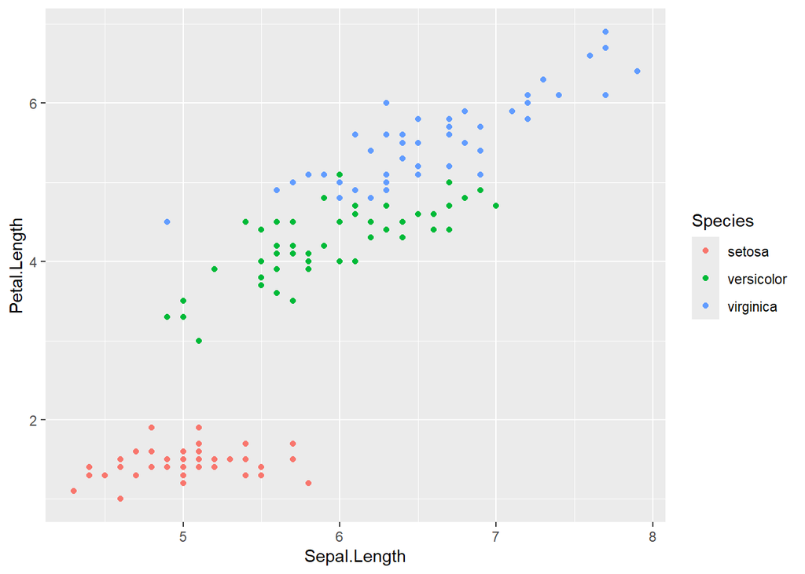

```r
# 以iris为例
library(ggplot2)
data(iris)

# 绘图
pic <- ggplot(iris,aes(Sepal.Length,Petal.Length,colour = Species)) +
  geom_point()
print(pic)
```

更改图例

我们可以借助属性”legend.position”删除图例，并得到相应的输出 −

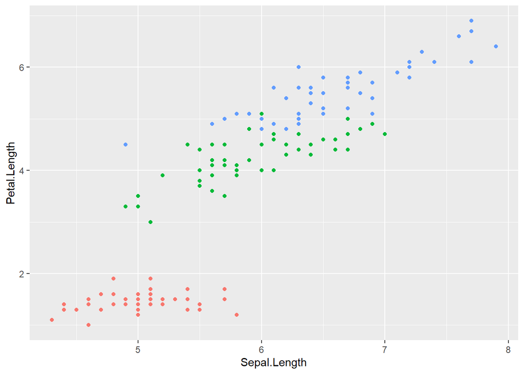

```r
pic + theme(legend.position = 'none')  # 删除图例
```

用属性”element_blank()“隐藏图例的标题，

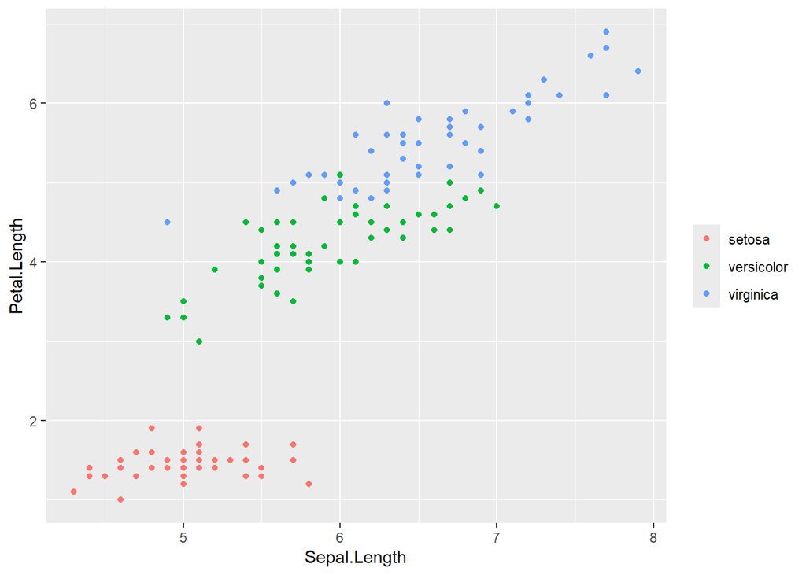

```r
pic + theme(legend.title = element_blank())  # 隐藏图例标题
```

更改图例位置，根据需要使用图例位置。此属性用于生成准确的绘图表示。

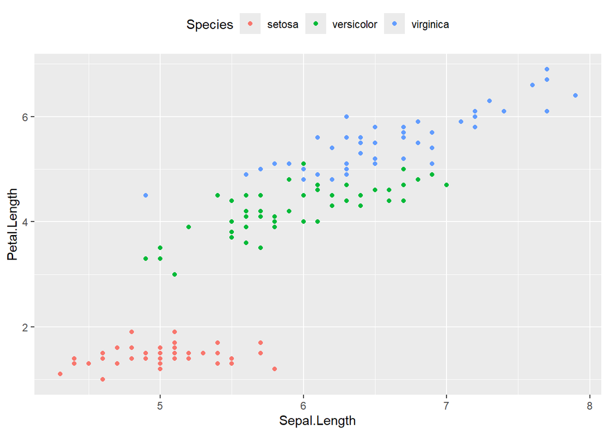

```r
 #更改图例位置
pic + theme(legend.position="top") # 图例在顶部
```